# Callbacks

## Table of Contents

1. Introduction
2. Setup
3. Helper Functions
4. Data
5. Model
6. Built-in callbacks  
   6.1. TensorBoard  
   6.2. ModelCheckpoint  
   6.3. EarlyStopping  
   6.4. CSVLogger  
   6.5. LearningRateScheduler  
   6.6. ReduceLROnPlateau
7. Custom callbacks  
   7.1. Simple Custom Callback  
   7.2. Detect overfitting  
   7.3. Visualize Predictions
8. References

## 1. Introduction

In Keras, Callback is a Python class designed to be subclassed for specific functionality.

It provides a set of methods that are called at various stages of:

- Training (batch/epoch start and end)
- Testing
- Predicting

Callbacks help monitor internal states and statistics during training.

The methods of callbacks can be triggered at different stages of:

- Training
- Evaluation
- Inference

Users can supply a list of callbacks to the following `tf.keras.Model` methods:

- fit()
- fit_generator()
- evaluate()
- evaluate_generator()
- predict()
- predict_generator()

**Note** The difference between fit() and fit_generator() in Keras lies in how they handle data input. model.fit() is used when the entire dataset fits into memory and it takes NumPy arrays or TensorFlow tensors as input; model.fit_generator() is used for large datasets that do not fit into memory and it takes a data generator (yielding batches) instead of NumPy arrays.

## 2. Setup

```python
import os
import math
import io
import numpy as np
import pandas as pd
import tensorflow as tf
from tensorflow.keras import layers, models
from tensorflow.keras.callbacks import (TensorBoard, EarlyStopping, LearningRateScheduler,
                                        ModelCheckpoint, CSVLogger, ReduceLROnPlateau)
import matplotlib.pyplot as plt
from PIL import Image
from IPython.display import Image as IPyImage
import imageio
```

## 3. Helper Functions

```python
# plot history
def plot_history(history):
    plt.plot(history.history['loss'], label='Training Loss')
    plt.plot(history.history['val_loss'], label='Validation Loss')
    plt.xlabel('Epochs')
    plt.ylabel('Loss')
    plt.legend()
    plt.show()
```

```python
# Visualization utilities
plt.rc('font', size=20)
plt.rc('figure', figsize=(15, 3))

def display_digits(inputs, outputs, ground_truth, epoch, n=10):
    plt.clf()

    plt.yticks([])
    plt.grid(None)
    inputs = np.reshape(inputs, [n, 28, 28])
    inputs = np.swapaxes(inputs, 0, 1)
    inputs = np.reshape(inputs, [28, 28*n])
    plt.imshow(inputs)
    plt.xticks([28*x+14 for x in range(n)], outputs)
    for i,t in enumerate(plt.gca().xaxis.get_ticklabels()):
        if outputs[i] == ground_truth[i]:
            t.set_color('green')
        else:
            t.set_color('red')
    plt.grid(None)
```

## 4 Data

We will use a built-in TensorFlow dataset, specifically the Boston Housing dataset, which predicts house prices based on certain features.

```python
# Load dataset
(x_train, y_train), (x_test, y_test) = tf.keras.datasets.boston_housing.load_data()

type(x_train), type(y_train)
```

```
(numpy.ndarray, numpy.ndarray)
```

## 5. Model

We will define a simple model to demonstrate the use of callbacks later.

```python
# build and compile a model
def build_compile_model():
    # Build a Sequential model
    model = models.Sequential([
        layers.Dense(64, activation='relu', input_shape=(x_train.shape[1],)),  # 13 features in input
        layers.Dense(32, activation='relu'),
        layers.Dense(1)  # Output layer for regression (single continuous value)
    ])

    # Compile
    model.compile(optimizer='adam', loss='mean_squared_error', metrics=['mae'])

    return model
```

## 6. Built-in Callbacks

### 6.1. [TensorBoard](https://keras.io/api/callbacks/tensorboard/)

Enable visualizations for TensorBoard.

```python
!rm -rf logs
```

```python
logdir = os.path.join("logs", datetime.datetime.now().strftime("%Y%m%d-%H%M%S"))
tensorboard_callback = tf.keras.callbacks.TensorBoard(logdir)
```

```python
model_1 = build_compile_model()

history_1 = model_1.fit(x_train,
          y_train,
          epochs=50,
          verbose=0,
          validation_data=(x_test, y_test),
          callbacks=[tensorboard_callback])
```

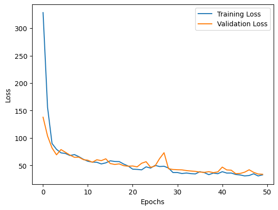

```python
plot_history(history_1)
```

We can launch TensorBoard with:

- %tensorboard --logdir logs

or, from the command line:

- Navigate to the log directory:
  - cd path/to/logs ( in this example)
- Execute:
  - tensorboard --logdir /path/to/logs --port 8080
- Open the URL provided in the browser (e.g. http://localhost:8080).

After doing that, we will see something like this:

[figure not shown]

### 6.2. [ModelCheckpoint](https://keras.io/api/callbacks/model_checkpoint/)

Callback to save the Keras model or model weights at some frequency.

ModelCheckpoint callback is used in conjunction with training using model.fit() to save a model or weights (in a checkpoint file) at some interval, so the model or weights can be loaded later to continue the training from the state saved.

A few important options:

- Whether to only keep the model that has achieved the "best performance" so far, or whether to save the model at the end of every epoch regardless of performance.
- Definition of "best"; which quantity to monitor and whether it should be maximized or minimized.
- The frequency it should save at. Currently, the callback supports saving at the end of every epoch, or after a fixed number of training batches.
- Whether only weights are saved, or the whole model is saved.

### Basic example

```python
model_2 = build_compile_model()

model_2.fit(x_train,
          y_train,
          epochs=5,
          validation_data=(x_test, y_test),
          verbose=0,
          callbacks=[ModelCheckpoint('weights.{epoch:02d}-{val_loss:.2f}.h5', verbose=1),
          ])
```

```
Epoch 1: saving model to weights.01-167.34.h5

Epoch 2: saving model to weights.02-148.53.h5

Epoch 3: saving model to weights.03-73.71.h5

Epoch 4: saving model to weights.04-80.52.h5

Epoch 5: saving model to weights.05-75.27.h5
```

```
<keras.src.callbacks.History at 0x7e9459b58520>
```

In the previous example:

- 'weights.{epoch:02d}-{val_loss:.2f}.h5' specifies the filename format for saving the model weights.
  - {epoch:02d}: The epoch number, padded to two digits (e.g., 01, 02, etc.).
  - {val_loss:.2f}: The validation loss, formatted to two decimal places.
  - .h5: The file format for the saved model weights.
- Example output filenames:
  - weights.01-0.45.h5
  - weights.02-0.43.h5
- verbose=1: This setting tells the callback to print a message whenever it saves the model weights (e.g., "Epoch 1: saving model...").

[figure not shown]

### Save only the best model

```python
model_checkpoint_callback = ModelCheckpoint(
    filepath='models/model.keras',
    monitor='mae',
    mode='min',
    save_best_only=True) #it only saves when the model is considered the "best", according to the metric
                            # specified

model_3 = build_compile_model()

model_3.fit(x_train,
          y_train,
          epochs=5,
          validation_data=(x_test, y_test),
          verbose=0,
          callbacks=[model_checkpoint_callback,])
```

```
<keras.src.callbacks.History at 0x7e9454049330>
```

```python
!ls models
```

```
model.keras
```

Now, we can resume the training with the best model so far.

```python
# load the model

from tensorflow.keras.models import load_model

model = load_model('models/model.keras')
```

```python
# resume training
model.fit(x_train, y_train, epochs=5, validation_data=(x_test, y_test))
```

```
<keras.src.callbacks.History at 0x7e944fb7de10>
```

### 6.3. [EarlyStopping](https://keras.io/api/callbacks/early_stopping/)

Stop training when a monitored metric has stopped improving.

Is a technique used to prevent overfitting.

```python
# a model that has likely overfit.
def build_compile_model_2():
    # Build a Sequential model
    model = models.Sequential([
        layers.Dense(256, activation='relu', input_shape=(x_train.shape[1],)),
        layers.Dense(128, activation='relu'),
        layers.Dense(1)
    ])

    # Compile
    model.compile(optimizer='adam', loss='mean_squared_error', metrics=['mae'])

    return model



model_4 = build_compile_model_2()

history_4 = model_4.fit(x_train,
          y_train,
          epochs=200,
          verbose=0,
          validation_data=(x_test, y_test))
```

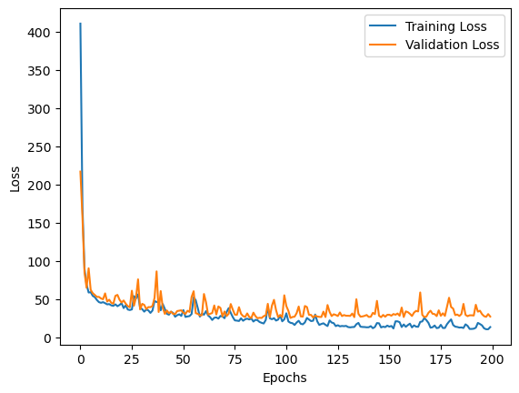

```python
plot_history(history_4)
```

We can see that train_loss keeps improving, but val_loss remains essentially the same after a certain epoch, indicating overfitting. To address this problem, we will use early stopping.

```python
model_5 = build_compile_model_2()

history_5 = model_5.fit(x_train,
          y_train,
          epochs=200,
          verbose=0,
          validation_data=(x_test, y_test),
          callbacks=[EarlyStopping(
              patience=20,
              mode='min',
              monitor='mae',
              restore_best_weights=True,
              verbose=1)
          ])
```

```
Restoring model weights from the end of the best epoch: 135.
Epoch 155: early stopping
```

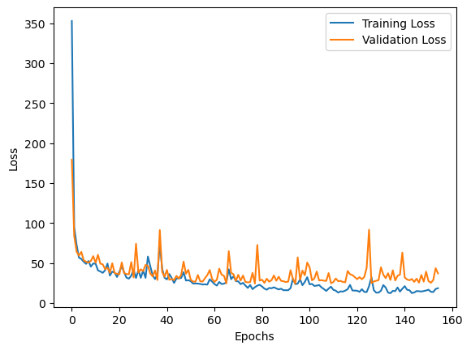

```python
plot_history(history_5)
```